# Week 5 Lab: Sensors & ADC Applications

EE0827 Embedded System Applications

## Overview

**Two analog sensors → STM32 ADC**

- K-type thermocouple + LM741 amplifier → PA0
- LDR (Light Dependent Resistor) → PA1

| Part | Topic | Time |
| --- | --- | --- |
| 1 | CubeMX ADC Configuration | 15 min |
| 2 | Thermocouple + Amplifier | 30 min |
| 3 | Light Sensor | 20 min |
| 4 | Digital Filtering | 15 min |

# Part 1: CubeMX ADC Configuration

## Step 1.1–1.2: New Project & ADC Pins

1. Create new STM32 project for **Nucleo-F401RE**
2. Name it `W05_Sensors_ADC`
3. In Pinout view:
   - **PA0** → ADC1_IN0 (Temperature)
   - **PA1** → ADC1_IN1 (Light)

## Step 1.3: ADC Parameters

Navigate to **Analog → ADC1**:

| Parameter | Value |
| --- | --- |
| Scan Conversion Mode | **Enabled** |
| Number of Conversions | **2** |

**Rank 1:** Channel 0 (PA0 — thermocouple), Sampling Time 84 Cycles

**Rank 2:** Channel 1 (PA1 — LDR), Sampling Time 84 Cycles

## Why These ADC Settings?

**Scan Conversion Mode** — When disabled, the ADC converts only one channel per trigger. When enabled, it converts multiple channels in sequence. We enable it because we have **two sensors** (thermocouple on CH0, LDR on CH1).

**Number of Conversions = 2** — Tells the scan sequencer how many channels to cycle through. Matches our two ADC inputs.

**Rank** — The conversion order. Rank 1 is converted first, Rank 2 second. In our code, we override the rank at runtime with `read_adc_channel()`, so the CubeMX rank order is just a default.

**Sampling Time = 84 Cycles** — How long the ADC holds the input before converting. Longer = more accurate for high-impedance sources. Our amplifier output has $R_p = 1\,\text{k}\Omega$ in series, so 84 cycles gives the internal sample capacitor enough time to settle.

## Step 1.4–1.5: UART & Generate

Navigate to **Connectivity → USART2**:

| Parameter | Value |
| --- | --- |
| Mode | Asynchronous |
| Baud Rate | 115200 |

Then: **Save → Project → Generate Code**

# Part 2: Thermocouple + Amplifier

## Circuit

[figure not shown]

LM741 thermocouple amplifier

## Wiring Table

The thermocouple is coaxial: **center wire** = signal, **brass body** = ground.

| Connection | Details |
| --- | --- |
| TC center wire | LM741 pin 3 (+) |
| TC brass body | Circuit GND |
| $R_f$ (220kΩ) | Pin 6 → Pin 2 |
| $R_g$ (1kΩ) | Pin 2 → GND |
| Pin 7 (V+) | +12V bench supply |
| Pin 4 (V−) | −12V bench supply |
| $R_p$ (1kΩ) | Pin 6 → PA0 (protection) |
| Null pot | Pins 1 & 5, wiper → −12V |

Gain: $A_v = 1 + 220\text{k}/1\text{k} = 221$

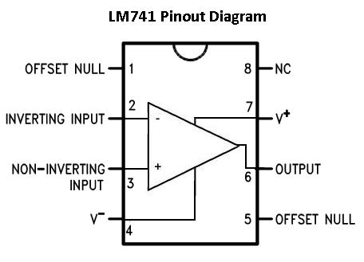

LM741 Pinout (DIP-8)

## Step 2.2: Null Offset

1. Set bench supply to **±12V** (series mode)
2. **Short** TC center wire to brass body (0mV input)
3. Measure pin 6 with multimeter
4. Turn offset null pot until output ≈ **0.000V**
5. Remove short, reconnect thermocouple
6. Warm tip with finger — output should increase
7. Confirm output < 3.3V, then connect $R_p$ to **PA0**

## Step 2.3: ADC Reading Code

```c
/* USER CODE BEGIN Includes */
#include <stdio.h>
#include <string.h>
/* USER CODE END Includes */

/* USER CODE BEGIN PV */
uint16_t adc_temp_raw = 0;
float temp_voltage = 0;
char uart_buf[64];
/* USER CODE END PV */
```

`stdio.h` for `sprintf`, `string.h` for `strlen`. `uart_buf` is a shared buffer for formatting UART messages.

## Step 2.3: ADC Reading Code (cont.)

```c
/* USER CODE BEGIN 0 */
uint16_t read_adc_channel(uint8_t channel) {
    ADC_ChannelConfTypeDef sConfig = {0};
    sConfig.Channel = (channel == 0) ? ADC_CHANNEL_0 : ADC_CHANNEL_1;
    sConfig.Rank = 1;
    sConfig.SamplingTime = ADC_SAMPLETIME_84CYCLES;

    HAL_ADC_ConfigChannel(&hadc1, &sConfig);
    HAL_ADC_Start(&hadc1);
    HAL_ADC_PollForConversion(&hadc1, 10);
    return HAL_ADC_GetValue(&hadc1);
}
/* USER CODE END 0 */
```

Selects ADC channel 0 or 1 at runtime, starts a single conversion, waits for it to finish, and returns the 12-bit result (0–4095).

## Step 2.4: Main Loop

```c
while (1) {
    adc_temp_raw = read_adc_channel(0);
    temp_voltage = (adc_temp_raw / 4095.0f) * 3.3f;

    sprintf(uart_buf, "TC: ADC=%4d, V=%.3fV\r\n",
            adc_temp_raw, temp_voltage);
    HAL_UART_Transmit(&huart2, (uint8_t *)uart_buf,
                      strlen(uart_buf), HAL_MAX_DELAY);
    HAL_Delay(500);
}
```

Reads channel 0 (thermocouple), converts the raw ADC count to voltage ($V = \frac{ADC}{4095} \times 3.3$), formats it into a string, and sends it over UART every 500ms. Build, flash, open serial terminal at 115200 baud. Pinch the thermocouple tip — ADC should increase.

# Part 3: Light Sensor

## LDR Voltage Divider

[figure not shown]

LDR circuit

$$V_{out} = 3.3\text{V} \times \frac{R_{LDR}}{10\text{k}\Omega + R_{LDR}}$$

| Condition | Expected |
| --- | --- |
| Bright | ~0.3V |
| Room light | ~1.65V |
| Dark | ~3.0V |

## Step 3.3: Dual Sensor Code

```c
/* USER CODE BEGIN PV */
uint16_t adc_light_raw = 0;
float light_voltage = 0;
float light_percent = 0;
/* USER CODE END PV */

while (1) {
    adc_temp_raw = read_adc_channel(0);
    temp_voltage = (adc_temp_raw / 4095.0f) * 3.3f;

    adc_light_raw = read_adc_channel(1);
    light_voltage = (adc_light_raw / 4095.0f) * 3.3f;
    light_percent = 100.0f - (light_voltage / 3.3f * 100.0f);

    sprintf(uart_buf, "TC: %.3fV | Light: %.0f%%\r\n",
            temp_voltage, light_percent);
    HAL_UART_Transmit(&huart2, (uint8_t *)uart_buf,
                      strlen(uart_buf), HAL_MAX_DELAY);
    HAL_Delay(500);
}
```

Reads both channels sequentially. Light percentage is inverted because the LDR divider outputs high voltage in the dark (high $R_{LDR}$) and low voltage in bright light (low $R_{LDR}$). Both readings are printed on a single UART line.

# Part 4: Digital Filtering

## Moving Average Filter

```c
/* USER CODE BEGIN PV */
#define FILTER_SIZE 8
uint16_t temp_buffer[FILTER_SIZE] = {0};
uint16_t light_buffer[FILTER_SIZE] = {0};
uint8_t filter_index = 0;
uint32_t temp_sum = 0, light_sum = 0;
/* USER CODE END PV */

uint16_t filter_update(uint16_t *buffer, uint32_t *sum,
                       uint16_t sample) {
    *sum -= buffer[filter_index];
    buffer[filter_index] = sample;
    *sum += sample;
    return *sum / FILTER_SIZE;
}
```

Circular buffer of 8 samples. Each call subtracts the oldest sample from the running sum, overwrites it with the new sample, adds it to the sum, and returns the average. O(1) per update — no need to re-sum the entire buffer.

## Filtered Main Loop

```c
while (1) {
    adc_temp_raw = read_adc_channel(0);
    uint16_t temp_filt = filter_update(
        temp_buffer, &temp_sum, adc_temp_raw);

    adc_light_raw = read_adc_channel(1);
    uint16_t light_filt = filter_update(
        light_buffer, &light_sum, adc_light_raw);

    filter_index = (filter_index + 1) % FILTER_SIZE;

    sprintf(uart_buf, "Raw: T=%4d L=%4d | Filt: T=%4d L=%4d\r\n",
            adc_temp_raw, adc_light_raw, temp_filt, light_filt);
    HAL_UART_Transmit(&huart2, (uint8_t *)uart_buf,
                      strlen(uart_buf), HAL_MAX_DELAY);
    HAL_Delay(100);
}
```

Prints both raw and filtered values side by side so you can compare. The `filter_index` wraps around with modulo — both channels share the same index since they’re sampled together. Delay is reduced to 100ms for faster visual feedback.

## Observe

1. Touch LDR wire briefly — raw spikes, filtered stays smooth
2. Blow on thermocouple — gradual filtered response

**Raw values jitter, filtered values stay smooth.**